# U4. El gobierno de Guido y la crisis (1962–1963)

Historia Económica Argentina · Clase 19

Sebastian Freille

Universidad Nacional de Córdoba

# Apertura y hoja de ruta

## Dónde quedamos

- El **desarrollismo de Frondizi** (1958–1962) terminó en crisis: devaluación, recesión y caída del gobierno en marzo de 1962.
- La estrategia de capitalizar el país vía deuda e IED chocó con la **restricción externa** cuando el flujo de capitales se cortó.
- Hoy analizamos el **interregno de Guido**: una transición política convulsa y una política económica ortodoxa que no logró revertir el estancamiento.

**Idea clave**

El interregno de 1962–1963 reveló que **la ortodoxia sola no bastaba** para corregir las tensiones estructurales acumuladas desde los años cuarenta.

## La pregunta de hoy

> ¿Por qué el gobierno de **Guido** no pudo estabilizar la economía? ¿Qué problemas estructurales —restricción externa, inflación crónica, fragilidad política— quedaron como **herencia** para 1963?

## Mapa de la clase

1. **Bloque 1 — Crisis de 1962:** el fin del desarrollismo y la caída de Frondizi.
2. **Bloque 2 — El interregno de Guido:** transición militar, devaluación y ortodoxia.
3. **Bloque 3 — Diagnóstico estructural:** el *stop-and-go* y la restricción externa.
4. **Bloque 4 — Evaluación:** fin de una etapa y bases para el crecimiento.

# Bloque 1. Crisis de 1962

## [1.1] El fin del programa

- Hacia 1961 el déficit comercial crecía y la presión sindical por salarios se intensificaba.
- El **conflicto ferroviario** obligó al gobierno a ceder; el BCRA lo financió con **emisión**.
- A fines de 1961 la devaluación aparecía como inevitable; en marzo de 1962, además de la devaluación, cayó el gobierno.

**El golpe del muerte**

La política monetaria restrictiva y la fiscal “sana” se derrumbaron cuando el BCRA emitió para financiar la “solución” ferroviaria. Eso acabó con la credibilidad del plan de estabilización.

Gerchunoff y Llach (2007), cap. 6.

## [1.2] Herencia económica

[output not shown]

Gerchunoff y Llach (2007), cap. 6; Díaz Alejandro (1970), cuadros 2-1 y 2-5.

# Bloque 2. El interregno de Guido

## [2.1] Transición militar

- **José María Guido** (presidente del Senado) fue designado por los militares tras la caída de Frondizi.
- El poder real residía en las Fuerzas Armadas, divididas en **azules** (legalistas) y **colorados** (dictadura permanente).
- A los seis meses triunfaron los azules; se convocaron a elecciones para **julio de 1963**, aunque con el **peronismo proscripto**.

**Democracia restringida**

El regreso a la constitucionalidad era deseable para los azules, pero solo si excluía al peronismo. El **20 % de votos en blanco** en 1963 sería la segunda minoría.

Gerchunoff y Llach (2007), cap. 6.

## [2.2] Política económica

- **Devaluación > 50 %** para detener la sangría de reservas.
- **Ortodoxia**: control del déficit fiscal y de la emisión monetaria.
- Guido tuvo **cuatro ministros de Economía** en poco más de un año.
- Se intentó reequilibrar **precios relativos** para compatibilizar el equilibrio externo.

**Poco margen de maniobra**

No hubo mucho que Guido pudiera hacer más allá de buscar la ortodoxia. La situación de **recesión con inflación** se mantuvo durante todo su breve mandato.

Gerchunoff y Llach (2007), cap. 6; Eshag y Thorp (1965).

## [2.3] Resultados: estanflación

- La inflación continuó alta, en parte por efecto de la devaluación; fuerte **rechazo del peso**.
- La recesión de fines de 1962–mediados de 1963 pegó fuerte en el **empleo** (casi un 9 %).
- El canal de transmisión fue el **crédito**: al cortarse el externo, también lo hizo el interno; las empresas contrajeron producción y vendieron stocks.

**Stagflation temprana**

Argentina enfrentó una combinación de **recesión, desempleo e inflación persistente** antes de que el término *stagflation* se popularizara en la década de 1970.

Gerchunoff y Llach (2007), cap. 6.

# Bloque 3. Diagnóstico estructural

## [3.1] El mecanismo *stop-and-go*

- El ciclo aparecía cada vez que las necesidades de **divisas para importar** superaban las que podían generarse por **exportar**.
- La **devaluación** era la salida frecuente, pero tenía efectos recesivos: disminuía el consumo privado y el salario real.
- Luego, el aumento gradual de salarios nominales volvía a estimular la economía… hasta reabrir el déficit externo.

**Un patrón endémico**

El *stop-and-go* no era accidente de coyuntura: era la **expresión de una estructura productiva** que necesitaba divisas para crecer pero no las generaba.

Gerchunoff y Llach (2007), caps. 5–6; Eshag y Thorp (1965).

## [3.2] La restricción externa

- La **ISI** se había completado para muchas ramas industriales, pero persistía la **dependencia de insumos, maquinaria y equipo importados**.
- El **sesgo anti-exportador** —heredado del peronismo y reforzado por las devaluaciones recesivas— mantuvo estancadas las exportaciones.
- Sin flujo sostenido de capitales externos, cada ciclo expansivo chocaba con el **techo externo**.

**El dilema**

Cualquier expansión de la demanda interna aumentaba las importaciones de insumos; pero el agro —único generador de divisas— había sido marginado por décadas de política de precios.

Gerchunoff y Llach (2007), cap. 6.

# Bloque 4. Evaluación

## [4.1] Fin de la etapa desarrollista

- El desarrollismo de Frondizi **sí planteó una estrategia de largo plazo**, a diferencia de la “no-estrategia” del primer peronismo.
- Pero la **viabilidad política** de las reformas era frágil: el escándalo del petróleo, la conflictividad social y la dependencia del capital externo lo desgastaron.
- La comparación con Brasil (Kubitschek) es reveladora: allí el *desenvolvimentismo* contó con mayor estabilidad política y coaliciones más amplias.

**¿Fracaso total?**

El desarrollismo no resolvió la restricción externa ni la inflación, pero dejó una **base industrial más diversificada** y demostró que el crecimiento sostenido requería flujos de capital estables.

Gerchunoff y Llach (2007), cap. 6; Hirschmann (1968).

## [4.2] Tres décadas de estancamiento

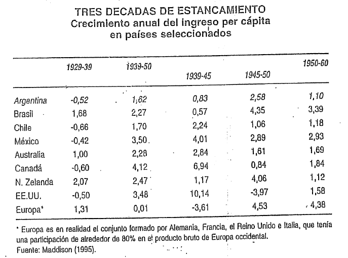

Maddison (1995), en Gerchunoff y Llach (2007), cap. 6.

## [4.3] Bases para 1963

- Quedaban desafíos pendientes: definir el **perfil productivo**, el rol del Estado y la **inserción externa**.
- La **recesión prolongada** y el desempleo creciente crearon condiciones para una **reactivación** por vía de demanda.
- El **tipo de cambio** estaba menos sobrevaluado que en 1961, lo que abría espacio para las exportaciones.

**Contexto de Illia**

Guido no pudo estabilizar, pero dejó un **escenario más equilibrado en precios relativos** y una economía con **capacidad ociosa** lista para reactivarse. Ese es el punto de partida de 1963.

Gerchunoff y Llach (2007), cap. 6.

# Cierre

## Ideas fuerza

1. La **caída de Frondizi** (marzo 1962) cerró la etapa desarrollista: devaluación, recesión y crisis de balanza de pagos.
2. El **interregno de Guido** aplicó ortodoxia sin éxito: cuatro ministros, devaluación del 50 %, stagflation y desempleo cercano al 9 %.
3. El *stop-and-go* no era coyuntural: reflejaba una estructura productiva **dependiente de divisas** que no las generaba.
4. El **sesgo anti-exportador** y la **fragilidad fiscal** eran legados estructurales que ningún gobierno había resuelto desde 1946.
5. A mediados de 1963, sin embargo, el **tipo de cambio reequilibrado** y la **capacidad ociosa** ofrecían una ventana para el crecimiento.

## Preguntas para llevarse

- ¿Fue el fracaso del desarrollismo **inevitable** o resultado de errores de implementación y fragilidad política?
- ¿Por qué la **ortodoxia** de Guido no logró estabilizar precios ni reactivar la actividad?
- ¿Es posible sostener el crecimiento en una economía con **restricción externa estructural** sin acceso a flujos de capital sostenidos?
- ¿Qué lecciones dejó el interregno para el diseño de política económica en 1963?

## Bibliografía de la clase

**Obligatoria**

- **Gerchunoff, P. y Llach, L. (2007).** *El ciclo de la ilusión y el desencanto*, **cap. 6**.
- **Eshag, E. y Thorp, R. (1965).** “Las consecuencias económicas y sociales de las políticas ortodoxas aplicadas en la Argentina durante los años de postguerra”.
- **Díaz Alejandro, C. (1970).** *Ensayos sobre la historia económica argentina*, cuadros 2-1 y 2-5.

**Complementaria**

- **Hirschmann, A. O. (1968).** “The political economy of import-substituting industrialization in Latin America”.
- **De Pablo, J. C. (2005).** *La economía argentina en la segunda mitad del siglo XX*, tomo I, cap. 4.

La bibliografía completa por unidad está en el programa de la asignatura.